# Tree Biomass and Barplots

Scott Pitz

October 30, 2017

## Goals for this script and assignment

- Data wrangling
- Summarize our data
- Make a Barchart - This will be useful for your projects
- Go over ANOVAs in more detail

Lets get going!

### 1. Data wrangling

Download the data files into the same directory as your r script will be located. I’ve placed them in a folder on the Blackboard page. You should use the files from Blackboard because I had to change the formatting on a couple of the files.

Link to E-Learning page - https://elearning.villanova.edu

Lets get the code started as we always do:

```r
# Clear workspace

rm(list=ls(all=T))

#this loads a package that has already been installed
library(ggplot2)
```

#### Adulting

We are going to put on our big kid underpants and do the data wrangling ourselves this time.

First we will need some new packages to get this done. I know you guys secretly love .csv files and some of you were kind enough to send them to me in that format. But let’s try to load the data straight from Excel this time.

Just uncomment and change the line of code you need.

#### Set your working directory and load a new package

```r
#set your working directory for your computer
setwd("C:/Users/Pitz/Documents/GitHub/Tree Biomass and Barcharts/") #pc format
#setwd("/Users/Your Name/Desktop/") #mac format
```

#### Load some new packages

I normally like to do this at the beginning of the script but it’s a personal preference. You just need to load the package before you call a function located within it.

Again, uncomment the lines of code, in this case the **install.packages** if you need to.

```r
#install.packages("xlsx") #install package
#still need to load it
library(xlsx) #help read excel files and sheets
```

#### Load first excel file

Load the first sheet from the first file by running the following lines of code.

```r
group1plot1 <- read.xlsx("Tree Data Julia.xlsx", 1) # read first sheet
head(group1plot1)
```

```
##   Tree.Number Circumference..cm. DBH..cm.      Species
## 1           1                225 71.65605    White Oak
## 2           2                 61 19.42675    Black Gum
## 3           3                 89 28.34395      Red Oak
## 4           4                107 34.07643    Red Maple
## 5           5                 64 20.38217 Chestnut Oak
## 6           6                 45 14.33121    Red Maple
```

Load the second sheet.

```r
group1plot2 <- read.xlsx("Tree Data Julia.xlsx", 2) # read second sheet
head(group1plot2)
```

```
##   Tree.Number Circumference..cm.  DBH..cm.   Species
## 1           1              104.0 33.121019   Red Oak
## 2           2               24.0  7.643312 Black Gum
## 3           3               12.0  3.821656 Black Gum
## 4           4               42.3 13.471338 Black Gum
## 5           5               69.8 22.229299 Black Gum
## 6           6               35.2 11.210191 Black Gum
```

### Change column names

We are probably going to do some merges later on so lets keep the column names consistent between data files.

```r
colnames(group1plot2) <- c("treeNum", "Cir", "dbh", "sp")
head(group1plot2)
```

```
##   treeNum   Cir       dbh        sp
## 1       1 104.0 33.121019   Red Oak
## 2       2  24.0  7.643312 Black Gum
## 3       3  12.0  3.821656 Black Gum
## 4       4  42.3 13.471338 Black Gum
## 5       5  69.8 22.229299 Black Gum
## 6       6  35.2 11.210191 Black Gum
```

### Add Columns

Let’s add plot and group columns.

```r
group1plot2$plot <- 2
group1plot2$group <- 1
head(group1plot2)
```

```
##   treeNum   Cir       dbh        sp plot group
## 1       1 104.0 33.121019   Red Oak    2     1
## 2       2  24.0  7.643312 Black Gum    2     1
## 3       3  12.0  3.821656 Black Gum    2     1
## 4       4  42.3 13.471338 Black Gum    2     1
## 5       5  69.8 22.229299 Black Gum    2     1
## 6       6  35.2 11.210191 Black Gum    2     1
```

After running the **head()** command we can see that columns are added and names are changed. Do the same for the other dataframe.

```r
colnames(group1plot1) <- c("treeNum", "Cir", "dbh", "sp")
group1plot1$plot <- 2
group1plot1$group <- 1
head(group1plot1)
```

```
##   treeNum Cir      dbh           sp plot group
## 1       1 225 71.65605    White Oak    2     1
## 2       2  61 19.42675    Black Gum    2     1
## 3       3  89 28.34395      Red Oak    2     1
## 4       4 107 34.07643    Red Maple    2     1
## 5       5  64 20.38217 Chestnut Oak    2     1
## 6       6  45 14.33121    Red Maple    2     1
```

### Load rest of data

Load more data, change column names and add columns if needed.

```r
group2 <- read.xlsx("Tree_Data tracy.xlsx", 1) # read first sheet
head(group2)
```

```
##   Tree.number Circumference..CM.  DBH..CM.         Species Plot.Number
## 1           1                 16  5.092958        Fraxinus           1
## 2           2                188 59.842259  Quercus prinus           1
## 3           3                 86 27.374650   Quercus rubra           1
## 4           4                  6  1.909859   standing dead           1
## 5           5                141 44.881694   Quercus rubra           1
## 6           6                 29  9.230987 Nyssa sylvatica           1
```

```r
colnames(group2) <- c("treeNum", "Cir", "dbh", "sp", "plot")
group2$group <- 2

head(group2)
```

```
##   treeNum Cir       dbh              sp plot group
## 1       1  16  5.092958        Fraxinus    1     2
## 2       2 188 59.842259  Quercus prinus    1     2
## 3       3  86 27.374650   Quercus rubra    1     2
## 4       4   6  1.909859   standing dead    1     2
## 5       5 141 44.881694   Quercus rubra    1     2
## 6       6  29  9.230987 Nyssa sylvatica    1     2
```

Another data file.

```r
group3 <- read.xlsx("Field Trip Data From Wetlands Group.xlsx", 1) # read first sheet
head(group3)
```

```
##   Tree.Number DBH.CM.          Species plot
## 1           1   44.50   American Beech    1
## 2           2   48.75          Red Oak    1
## 3           3   51.90          Red Oak    1
## 4           4   60.00          Red Oak    1
## 5           5    8.80     Yellow Birch    1
## 6           6    5.60 Eastern Sycamore    1
```

```r
colnames(group3) <- c("treeNum", "dbh", "sp", "plot")
group3$group <- 3

head(group3)
```

```
##   treeNum   dbh               sp plot group
## 1       1 44.50   American Beech    1     3
## 2       2 48.75          Red Oak    1     3
## 3       3 51.90          Red Oak    1     3
## 4       4 60.00          Red Oak    1     3
## 5       5  8.80     Yellow Birch    1     3
## 6       6  5.60 Eastern Sycamore    1     3
```

And another.

```r
group4 <- read.csv("Tree_Data_2017.csv") # read csv
head(group4)
```

```
##   ï..Plot.Number Diameter..cm.       DBH        Species
## 1              1            27  8.594367   Chestnut Oak
## 2              1            19  6.047888   Chestnut Oak
## 3              1            39 12.414086   Chestnut Oak
## 4              1           115 36.605637        Red Oak
## 5              1           163 51.884511        Red Oak
## 6              1            16  5.092958 American Beech
```

```r
colnames(group4) <- c("plot", "cir", "dbh", "sp")
group4$group <- 4

head(group4)
```

```
##   plot cir       dbh             sp group
## 1    1  27  8.594367   Chestnut Oak     4
## 2    1  19  6.047888   Chestnut Oak     4
## 3    1  39 12.414086   Chestnut Oak     4
## 4    1 115 36.605637        Red Oak     4
## 5    1 163 51.884511        Red Oak     4
## 6    1  16  5.092958 American Beech     4
```

Fifth group.

```r
group5 <- read.xlsx("Tree Hugging.xlsx", 1) # read first sheet
head(group5)
```

```
##   Tree.Number DBM..cm.     Species plot
## 1           1    47.00     Hickery    1
## 2           2    11.20   Black Gum    1
## 3           3    42.00     Hickery    1
## 4           4    17.00 Witch Hazel    1
## 5           5    17.00 Witch Hazel    1
## 6           6    86.87   Red Maple    1
```

```r
colnames(group5) <- c("treeNum", "dbh", "sp", "plot")
group5$group <- 5
head(group5)
```

```
##   treeNum   dbh          sp plot group
## 1       1 47.00     Hickery    1     5
## 2       2 11.20   Black Gum    1     5
## 3       3 42.00     Hickery    1     5
## 4       4 17.00 Witch Hazel    1     5
## 5       5 17.00 Witch Hazel    1     5
## 6       6 86.87   Red Maple    1     5
```

Sixth and final group, plot one.

```r
group6plot1 <- read.xlsx("Tree Data Evelyn.xlsx", 1) # read first sheet
head(group6plot1)
```

```
##   Tree.Number Circumference..cm. DBH..cm.  Species.
## 1           1                 63     20.1 Black Gum
## 2           2                 43     13.7 Black Gum
## 3           3                 52     16.6 Red Maple
## 4           4                 62     19.7 Black Gum
## 5           5                 62     19.7 Black Gum
## 6           6                 54     17.2 Black Gum
```

```r
colnames(group6plot1) <- c("treeNum", "cir", "dbh", "sp")
group6plot1$plot <- 1
group6plot1$group <- 6
head(group6plot1)
```

```
##   treeNum cir  dbh        sp plot group
## 1       1  63 20.1 Black Gum    1     6
## 2       2  43 13.7 Black Gum    1     6
## 3       3  52 16.6 Red Maple    1     6
## 4       4  62 19.7 Black Gum    1     6
## 5       5  62 19.7 Black Gum    1     6
## 6       6  54 17.2 Black Gum    1     6
```

Sixth and final group, plot two.

```r
group6plot2 <- read.xlsx("Tree Data Evelyn.xlsx", 2) # read second sheet
head(group6plot2)
```

```
##   Tree.Number Circumference..cm. DBH..cm.     Species.
## 1           1              453.9    144.5    Black Gum
## 2           2               35.0     11.1 Yellow Birch
## 3           3               49.8     15.9 Yellow Birch
## 4           4               48.0     15.3    Red Maple
## 5           5               41.1     13.1    Black Gum
## 6           6               64.7     20.6      Red Oak
```

```r
colnames(group6plot2) <- c("treeNum", "cir", "dbh", "sp")
group6plot2$plot <- 2
group6plot2$group <- 6
head(group6plot2)
```

```
##   treeNum   cir   dbh           sp plot group
## 1       1 453.9 144.5    Black Gum    2     6
## 2       2  35.0  11.1 Yellow Birch    2     6
## 3       3  49.8  15.9 Yellow Birch    2     6
## 4       4  48.0  15.3    Red Maple    2     6
## 5       5  41.1  13.1    Black Gum    2     6
## 6       6  64.7  20.6      Red Oak    2     6
```

Ok, that should be all of them. Now time to merge it all together.

#### Merge dataframes into one huge, Big League dataframe

So we are gonna smoosh all these dataframes into one large one using a vertical merge. To do that, we will use the **rbind** command.

```r
bigTreeData <- rbind(group1plot1, group1plot2, group2) # combine three dataframes
head(bigTreeData) #confirm there is some data there
```

```
##   treeNum Cir      dbh           sp plot group
## 1       1 225 71.65605    White Oak    2     1
## 2       2  61 19.42675    Black Gum    2     1
## 3       3  89 28.34395      Red Oak    2     1
## 4       4 107 34.07643    Red Maple    2     1
## 5       5  64 20.38217 Chestnut Oak    2     1
## 6       6  45 14.33121    Red Maple    2     1
```

There’s some data there but we should check to see if it all got there. We can use a command called **length()** to check the length of a vector, in this case, the length of the **dbh** column/vector.

```r
length(group1plot1$dbh)
```

```
## [1] 11
```

```r
length(group1plot2$dbh)
```

```
## [1] 46
```

```r
length(group2$dbh)
```

```
## [1] 37
```

```r
length(bigTreeData$dbh)
```

```
## [1] 94
```

As you can see 11+46+37=94, so Bob’s your uncle.

We have our methodology down, so we can write over **bigTreedata** with all the data and check the length.

```r
bigTreeData <- rbind(group1plot1, group1plot2, group2, group3, group4, group5, group6plot1, group6plot2) # combine all dataframes
```

```
## Error in rbind(deparse.level, ...): numbers of columns of arguments do not match
```

```r
length(bigTreeData$dbh)
```

```
## [1] 94
```

Oops, guess what didn’t work. As you can probably gather from the error, we have an issue with the columns. It also helps that we checked the length as we can see that it didn’t change.

Let’s look at the columns names and figure out whats going on.

```r
colnames(group1plot1)
```

```
## [1] "treeNum" "Cir"     "dbh"     "sp"      "plot"    "group"
```

```r
colnames(group1plot2)
```

```
## [1] "treeNum" "Cir"     "dbh"     "sp"      "plot"    "group"
```

```r
colnames(group2)
```

```
## [1] "treeNum" "Cir"     "dbh"     "sp"      "plot"    "group"
```

```r
colnames(group3)
```

```
## [1] "treeNum" "dbh"     "sp"      "plot"    "group"
```

```r
colnames(group4)
```

```
## [1] "plot"  "cir"   "dbh"   "sp"    "group"
```

```r
colnames(group5)
```

```
## [1] "treeNum" "dbh"     "sp"      "plot"    "group"
```

```r
colnames(group6plot1)
```

```
## [1] "treeNum" "cir"     "dbh"     "sp"      "plot"    "group"
```

```r
colnames(group6plot2)
```

```
## [1] "treeNum" "cir"     "dbh"     "sp"      "plot"    "group"
```

AS you can see the column names are not all the same. We are going to have to drop/keep some of the columns to make **rbind** work.

We just need **dbh, sp, plot, group**.

```r
# select columns "dbh", "sp", "plot", "group"
vars <- c("dbh", "sp", "plot", "group")

subgroup1plot1 <- group1plot1[vars]
subgroup1plot2 <- group1plot2[vars]
subgroup2 <- group2[vars]
subgroup3 <- group3[vars]
subgroup4 <- group4[vars]
subgroup5 <- group5[vars]
subgroup6plot1 <- group6plot1[vars]
subgroup6plot2 <- group6plot2[vars]

colnames(subgroup1plot1)
```

```
## [1] "dbh"   "sp"    "plot"  "group"
```

Ok, a vertical merge using **rbind** should work now.

```r
bigTreeData <- rbind(subgroup1plot1, subgroup1plot2, subgroup2, subgroup3, subgroup4, subgroup5, subgroup6plot1, subgroup6plot2) # combine all dataframes
length(bigTreeData$dbh)
```

```
## [1] 223
```

Alright, on to the summary.

### 2. Summarize our data

[figure not shown]

Me too.

We are going to use a command called **summarySE()** that will summarize our data by different variables. It also will give us the standard deviation, standard error, and confidence interval.

So we are going to first summarize our data by species. Before we use the summarySE() command lets see how many species there are using the **unique()** command.

```r
unique(bigTreeData$sp)
```

```
##  [1] White Oak             Black Gum             Red Oak
##  [4] Red Maple             Chestnut Oak          American Beech
##  [7] Yellow Birch          Fraxinus              Quercus prinus
## [10] Quercus rubra         standing dead         Nyssa sylvatica
## [13] Cherry                Quercus alba          Standing dead
## [16] Fagus grandifolia     Acer rubrum           Betula allegheniensis
## [19] Eastern Sycamore      Hickory               Tulip Popler
## [22] Yellow Birtch         Moutian Laural        Hickery
## [25] Witch Hazel           Standing Dead         Tulip Tree
## [28] Mountain Laurel       Jiickory              Red Oak
## [31] Yellow Birch
## 31 Levels: American Beech Black Gum Chestnut Oak Red Maple ... Yellow Birch
```

Well, that’s not good. And you thought we were done data wrangling. We will never be done. *Ever.*

Let’s look at the damage a different way using the **summarySE()** command.

```r
library(Rmisc) # you need this library
bySpecies <- summarySE(bigTreeData, measurevar="dbh", groupvars=c("sp"))
bySpecies
```

```
##                       sp  N       dbh        sd        se         ci
## 1         American Beech 19 24.097949 31.419132  7.208043  15.143537
## 2              Black Gum 56 16.123284 19.468757  2.601622   5.213767
## 3           Chestnut Oak 12 28.540652 20.160902  5.819951  12.809626
## 4              Red Maple 19 35.145991 32.389762  7.430721  15.611366
## 5                Red Oak 32 49.136204 40.180925  7.103051  14.486768
## 6              White Oak 11 51.611173 30.164843  9.095042  20.265017
## 7           Yellow Birch  9 10.208917  5.549377  1.849792   4.265629
## 8            Acer rubrum  1  9.867606        NA        NA        NaN
## 9  Betula allegheniensis  1 10.822536        NA        NA        NaN
## 10                Cherry  1 16.233804        NA        NA        NaN
## 11     Fagus grandifolia  1 35.650707        NA        NA        NaN
## 12              Fraxinus  1  5.092958        NA        NA        NaN
## 13       Nyssa sylvatica 15 11.841128  5.869591  1.515522   3.250471
## 14          Quercus alba  1 22.281692        NA        NA        NaN
```

[output cut: 17 more lines]

Oh crap. That’s not good. There’s definitely not 31 species at McKaig Woods. If you look carefully, you can see that there are some common names mixed with Latin names, and some misspellings. What the heck is a Jiickory?

So the lesson here is be careful how you enter your field data or it might cause you headaches later.

If you wondering about the NAs and a NaNs, it’s because there is only one of those species so you can’t calculate a standard deviation, etc.

Let’s go one by one, fix these, and commit to using the Latin names. We need to replace certain, errant values with the the ones we want to keep. We can do this using the following code, using American Beech as the first test case.

Before we can replace some of the variables we need to change the variable type from factors to characters. If you are curious about this, just ask me in class.

```r
bigTreeData$sp <- as.character(bigTreeData$sp)
bigTreeData$sp[bigTreeData$sp == "American Beech"] <- "Fagus grandifolia"
unique(bigTreeData$sp)
```

```
##  [1] "White Oak"             "Black Gum"
##  [3] "Red Oak"               "Red Maple"
##  [5] "Chestnut Oak"          "Fagus grandifolia"
##  [7] "Yellow Birch"          "Fraxinus"
##  [9] "Quercus prinus"        "Quercus rubra"
## [11] "standing dead"         "Nyssa sylvatica"
## [13] "Cherry"                "Quercus alba"
## [15] "Standing dead"         "Acer rubrum"
## [17] "Betula allegheniensis" "Eastern Sycamore"
## [19] "Hickory"               "Tulip Popler"
## [21] "Yellow Birtch"         "Moutian Laural"
## [23] "Hickery"               "Witch Hazel"
## [25] "Standing Dead"         "Tulip Tree"
## [27] "Mountain Laurel"       "Jiickory"
## [29] "Red Oak "              "Yellow Birch "
```

```r
bySpecies <- summarySE(bigTreeData, measurevar="dbh", groupvars=c("sp"))
bySpecies
```

```
##                       sp  N       dbh        sd        se         ci
## 1            Acer rubrum  1  9.867606        NA        NA         NA
## 2  Betula allegheniensis  1 10.822536        NA        NA        NaN
## 3              Black Gum 56 16.123284 19.468757  2.601622   5.213767
## 4                 Cherry  1 16.233804        NA        NA        NaN
## 5           Chestnut Oak 12 28.540652 20.160902  5.819951  12.809626
## 6       Eastern Sycamore  1  5.600000        NA        NA        NaN
## 7      Fagus grandifolia 20 24.675587 30.690052  6.862504  14.363387
## 8               Fraxinus  1  5.092958        NA        NA        NaN
## 9                Hickery  2 44.500000  3.535534  2.500000  31.765512
## 10               Hickory  7 23.971429 12.195179  4.609344  11.278659
## 11              Jiickory  1  7.000000        NA        NA        NaN
## 12       Mountain Laurel  2 14.300000 16.546299 11.700000 148.662595
## 13        Moutian Laural  1  3.501409        NA        NA        NaN
## 14       Nyssa sylvatica 15 11.841128  5.869591  1.515522   3.250471
```

[output cut: 16 more lines]

As you can see, “American Beech” is no longer among the unique values in the species column, there are 20 measurements of *Fagus grandifolia*, and there are now 30 unique occurrences instead of 31.

Let’s try another one, *Betula alleghaniensis*. As you can see there are quite a few aberrations of this one. We can make our code a little more elegant and short by combining multiple statements into one by using the “or” operator.

“or” is represented by the “|” symbol and is on your keyboard. You may have to hunt for it.

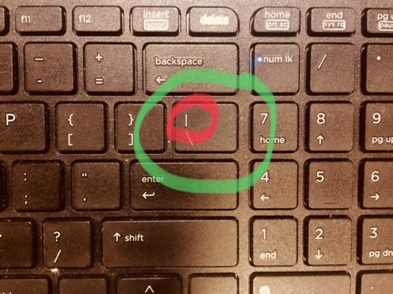

Using the following code, we can simplify the yellow Birch/*Betula alleghaniensis* occurrences in the data.

```r
bigTreeData$sp[bigTreeData$sp == "Yellow Birch" |
                 bigTreeData$sp == "Yellow Birch " |
                 bigTreeData$sp == "Yellow Birtch" |
                 bigTreeData$sp == "Betula allegheniensis"] <- "Betula alleghaniensis"
unique(bigTreeData$sp)
```

```
##  [1] "White Oak"             "Black Gum"
##  [3] "Red Oak"               "Red Maple"
##  [5] "Chestnut Oak"          "Fagus grandifolia"
##  [7] "Betula alleghaniensis" "Fraxinus"
##  [9] "Quercus prinus"        "Quercus rubra"
## [11] "standing dead"         "Nyssa sylvatica"
## [13] "Cherry"                "Quercus alba"
## [15] "Standing dead"         "Acer rubrum"
## [17] "Eastern Sycamore"      "Hickory"
## [19] "Tulip Popler"          "Moutian Laural"
## [21] "Hickery"               "Witch Hazel"
## [23] "Standing Dead"         "Tulip Tree"
## [25] "Mountain Laurel"       "Jiickory"
## [27] "Red Oak "
```

```r
bySpecies <- summarySE(bigTreeData, measurevar="dbh", groupvars=c("sp"))
bySpecies
```

```
##                       sp  N       dbh        sd        se         ci
## 1            Acer rubrum  1  9.867606        NA        NA         NA
## 2  Betula alleghaniensis 12 10.990373  5.255886  1.517244   3.339431
## 3              Black Gum 56 16.123284 19.468757  2.601622   5.213767
## 4                 Cherry  1 16.233804        NA        NA        NaN
## 5           Chestnut Oak 12 28.540652 20.160902  5.819951  12.809626
## 6       Eastern Sycamore  1  5.600000        NA        NA        NaN
## 7      Fagus grandifolia 20 24.675587 30.690052  6.862504  14.363387
## 8               Fraxinus  1  5.092958        NA        NA        NaN
## 9                Hickery  2 44.500000  3.535534  2.500000  31.765512
## 10               Hickory  7 23.971429 12.195179  4.609344  11.278659
## 11              Jiickory  1  7.000000        NA        NA        NaN
## 12       Mountain Laurel  2 14.300000 16.546299 11.700000 148.662595
## 13        Moutian Laural  1  3.501409        NA        NA        NaN
## 14       Nyssa sylvatica 15 11.841128  5.869591  1.515522   3.250471
## 15          Quercus alba  1 22.281692        NA        NA        NaN
## 16        Quercus prinus  1 59.842259        NA        NA        NaN
## 17         Quercus rubra  6 37.348360  8.848022  3.612190   9.285430
## 18             Red Maple 19 35.145991 32.389762  7.430721  15.611366
## 19               Red Oak 32 49.136204 40.180925  7.103051  14.486768
## 20              Red Oak   1 35.300000        NA        NA        NaN
## 21         standing dead  1  1.909859        NA        NA        NaN
## 22         Standing dead  8  4.496127  3.314257  1.171767   2.770788
## 23         Standing Dead  6 39.083333 17.990044  7.344405  18.879393
## 24          Tulip Popler  1 26.738030        NA        NA        NaN
## 25            Tulip Tree  2 65.500000 26.162951 18.500000 235.064788
## 26             White Oak 11 51.611173 30.164843  9.095042  20.265017
## 27           Witch Hazel  2 17.000000  0.000000  0.000000   0.000000
```

Cool, down to 27 unique values.

But see how an extra space, a wrong letter or an extra letter can cause you a headache.

Your first task on the assignment is: **to simplify this data down an replace the values until all the bad values are gone.**

Be very careful about typos and spelling here.

In the end your **summarySE()** command should output this:

```
##                         sp  N       dbh        sd        se        ci
## 1              Acer rubrum 20 33.882071 32.028595  7.161812 14.989844
## 2    Betula alleghaniensis 12 10.990373  5.255886  1.517244  3.339431
## 3                Carya sp. 10 26.380000 14.823765  4.687686 10.604282
## 4        Fagus grandifolia 20 24.675587 30.690052  6.862504 14.363387
## 5             Fraxinus sp.  1  5.092958        NA        NA       NaN
## 6    Hammamelis virginiana  2 17.000000  0.000000  0.000000  0.000000
## 7         Kalmia latifolia  3 10.700470 13.257445  7.654190 32.933320
## 8  Liriodendron tulipifera  3 52.579343 29.035842 16.763851 72.129029
## 9          Nyssa sylvatica 71 15.218603 17.544255  2.082120  4.152657
## 10   Platanus occidentalis  1  5.600000        NA        NA       NaN
## 11         Prunus serotina  1 16.233804        NA        NA       NaN
## 12            Quercus alba 12 49.167050 29.981375  8.654877 19.049257
## 13          Quercus prinus 13 30.948468 21.165033  5.870124 12.789902
## 14           Quercus rubra 39 46.967915 36.736239  5.882506 11.908511
## 15           Standing dead 15 18.158592 20.838652  5.380517 11.540061
```

The *Carya sp.* is a convention and stands for all species in the *Carya* genus, since we were having a hard time identifying them.

The reason we are spending so much time fixing our data and looking at this **summarySE()** command is that is is very easy to go from the **summarySE()** output to a nice looking barchart.

Also, learning how to replace bad values in a large data set is an important research and workplace skill. I’m thinking of you, Birdfriends! You should be able to simplify your large data set using these techniques and regular expressions.

### 3. Make a Barchart

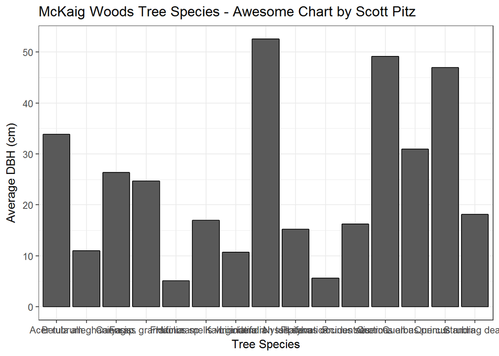

```r
bar<-ggplot(bySpecies, aes(x=sp, y=dbh)) +
  geom_bar(position=position_dodge(), stat="identity", colour="black")+
  theme_bw(base_size = 12)+
  labs(x="Tree Species",
       y="Average DBH (cm)",
       title= "McKaig Woods Tree Species - Awesome Chart by Scott Pitz")

bar
```

Its hard to read the labels, lets adjust them. I didn’t know how to do this, so I just googled it…“rotate labels ggplot2”

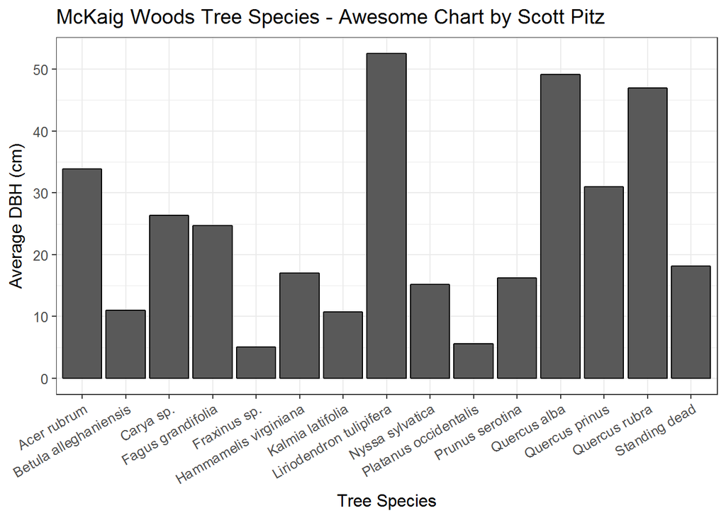

```r
#rotate text
bar <- bar + theme(axis.text.x=element_text(angle=30,hjust=1))

bar
```

Let’s add error bars. It’s common practice to use the standard deviation or standard error as the length of the error bars. Good thing we know how to use the **summarySE()** command. We will use standard error here.

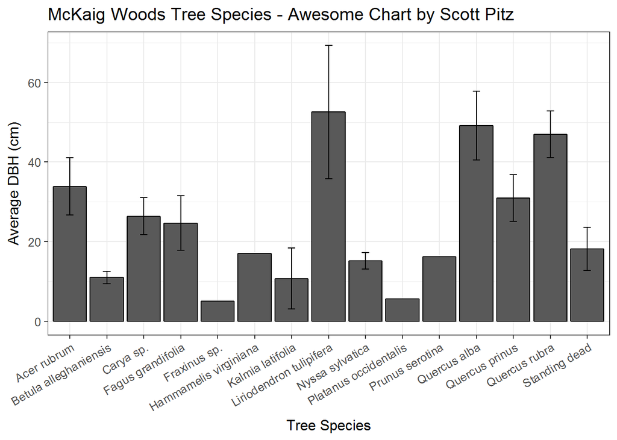

```r
# Error bars represent standard error of the mean
bar <- bar + geom_errorbar(aes(ymin=dbh-se, ymax=dbh+se),
                           width=.2,  # Width of the error bars
                           position=position_dodge(.9))

bar
```

If you have every had to add error bars to a barchart in Microsoft Excel, it’s difficult to articulate how much of a pain in the butt it is. If you haven’t had the pleasure, you are either avoiding something or living your best life. Only time will tell.

ggplot2 makes it “relatively” painless.

### 4. Go over ANOVAs in more detail

## So…Bad News…I lied.

In our previous assignment, I left out some parts of the ANOVA to keep things simple. I lied.

[figure not shown]

I’m sorry. Please take me back. Actually we’re stuck together, so you don’t have a choice. So let’s get this over with.

And honestly that was kinda an excuse to learn out to insert an image and pretend that I’m, like, totally up to speed on pop culture. Partial success!

## Tests for Normality and Variance

To run an ANOVA your data must meet two assumptions:

- Assumption 1: Data are normally distributed.
  - Test with a Shapiro-Wilk W
- Assumption 2: Variances are equal across groups.

### Tests for Normality

Before you can properly run an ANOVA you need to see if you data is “normal”. If you data is not normal you need to run different types of statistical tests, such as non-parametric stats which is beyond the scope of this course.

One test for Normality is called the Shapiro-Wilk. Its pretty easy to run but it needs to be run on each species.

```r
maple <- bigTreeData[bigTreeData$sp =="Acer rubrum",]
whiteOak <- bigTreeData[bigTreeData$sp =="Quercus alba",]

shapiro.test(maple$dbh)
```

```
##
##  Shapiro-Wilk normality test
##
## data:  maple$dbh
## W = 0.75246, p-value = 0.0001832
```

```r
shapiro.test(whiteOak$dbh)
```

```
##
##  Shapiro-Wilk normality test
##
## data:  whiteOak$dbh
## W = 0.88911, p-value = 0.1148
```

Thats the end of part one. We will deal with variances later.